# Nathan’s Hot Dog Eating Contest

2022-12-23

# Nathan’s Hot Dog Eating Contest

The goal is to visualize the winners of the contest each year and to highlight each new record established. To do so, I am going to need the *name* of the winner, the *year*, and *new* *record* info.

**N.B***:* The original idea of the graph comes from the awesome book “Visualize This” by Nathan Yau. Nevertheless, I am going to do it my way by scraping and organizing data instead of downloading the clean CSV file from [http://datasets.flowingdata.com/hot-dog-contest-winners.csv](http://datasets.flowingdata.com/hot-dog-contest-winners.csv%22,).

## Scrapping the data from Wikipedia

```r
# install.packages("tidyverse")
library(rvest)

URL = "https://en.wikipedia.org/wiki/Nathan%27s_Hot_Dog_Eating_Contest"
webpage = read_html(URL)

# get all tables on the wikipedia pages
tables <- webpage %>% html_elements("table")

# the second table is the one that contains our data
# R indices start with 1 :)
hdb_winners <- tables[2]
```

```r
hdb_winners
```

```
## {xml_nodeset (1)}
## [1] <table class="wikitable plainrowheaders sortable"><tbody>\n<tr>\n<th>Year ...
```

## Data Pre-processing

### Extracting the text from table rows

```r
hdb_winners_rows <- hdb_winners %>%
  html_elements("tr") %>%
  html_text2()
```

```r
print(hdb_winners_rows[1:5])
```

```
## [1] "Year\tWinner\n(and date, if prior to permanently moving all contests to Independence Day in 1997)\tHot dogs and buns\n(HDB)\tContest duration\tNote(s)"
## [2] "2022\tMEN'S\nJoey Chestnut\t63a\t10 min.\tMiki Sudo returns from her pregnancy to reclaim her title. After being shoved from the table, Joey Chestnut puts a protester who ran onto the stage during the event in a chokehold. Geoffrey Esper (47 HDB) finished second. James Webb (41 HDB) finished…
## [3] "WOMEN'S\nMiki Sudo\t40"
## [4] "2021\tMEN'S\nJoey Chestnut\t76\t10 min.\tThe event is held at Maimonides Park due to capacity restrictions and other health and safety requirements. Joey Chestnut breaks the world record with 76 HDB. Defending champion Miki Sudo was out due to her pregnancy."
## [5] "WOMEN'S\nMichelle Lesco\t30¾"
```

### Removing the header

```r
hdb_winners_rows <- hdb_winners_rows[-1]
```

```r
print(hdb_winners_rows[1:5])
```

```
## [1] "2022\tMEN'S\nJoey Chestnut\t63a\t10 min.\tMiki Sudo returns from her pregnancy to reclaim her title. After being shoved from the table, Joey Chestnut puts a protester who ran onto the stage during the event in a chokehold. Geoffrey Esper (47 HDB) finished second. James Webb (41 HDB) finished…
## [2] "WOMEN'S\nMiki Sudo\t40"
## [3] "2021\tMEN'S\nJoey Chestnut\t76\t10 min.\tThe event is held at Maimonides Park due to capacity restrictions and other health and safety requirements. Joey Chestnut breaks the world record with 76 HDB. Defending champion Miki Sudo was out due to her pregnancy."
## [4] "WOMEN'S\nMichelle Lesco\t30¾"
## [5] "2020\tMEN'S\nJoey Chestnut\t75\t10 min.\tFirst time event is being held indoors without fans caused by the COVID-19 pandemic. Joey Chestnut breaks the world record with 75 HDB. Darron Breeden (42 HDB) finished second. Nick Wehry (39.5 HDB) finished third. Miki Sudo breaks the women's world r…
```

### Splitting each row and storing it into a vector

We take data from 1997 till 2022 since data is inconsistent before and then split each row to extract the columns.

```r
winners <- c()
last_year <- 38
for ( i in 1:last_year ) {
  tmp <- strsplit(hdb_winners_rows[i], split = '\t')
  winners <- c(winners, tmp)
}
```

```r
print(hdb_winners_rows[1:4])
```

```
## [1] "2022\tMEN'S\nJoey Chestnut\t63a\t10 min.\tMiki Sudo returns from her pregnancy to reclaim her title. After being shoved from the table, Joey Chestnut puts a protester who ran onto the stage during the event in a chokehold. Geoffrey Esper (47 HDB) finished second. James Webb (41 HDB) finished…
## [2] "WOMEN'S\nMiki Sudo\t40"
## [3] "2021\tMEN'S\nJoey Chestnut\t76\t10 min.\tThe event is held at Maimonides Park due to capacity restrictions and other health and safety requirements. Joey Chestnut breaks the world record with 76 HDB. Defending champion Miki Sudo was out due to her pregnancy."
## [4] "WOMEN'S\nMichelle Lesco\t30¾"
```

### Sorting the table in ascending year order

```r
winners <- rev(winners)
```

```r
print(winners[35:38])
```

```
## [[1]]
## [1] "WOMEN'S\nMichelle Lesco" "30¾"
##
## [[2]]
## [1] "2021"
## [2] "MEN'S\nJoey Chestnut"
## [3] "76"
## [4] "10 min."
## [5] "The event is held at Maimonides Park due to capacity restrictions and other health and safety requirements. Joey Chestnut breaks the world record with 76 HDB. Defending champion Miki Sudo was out due to her pregnancy."
##
## [[3]]
## [1] "WOMEN'S\nMiki Sudo" "40"
##
## [[4]]
## [1] "2022"
## [2] "MEN'S\nJoey Chestnut"
## [3] "63a"
## [4] "10 min."
## [5] "Miki Sudo returns from her pregnancy to reclaim her title. After being shoved from the table, Joey Chestnut puts a protester who ran onto the stage during the event in a chokehold. Geoffrey Esper (47 HDB) finished second. James Webb (41 HDB) finished third."
```

We notice that during the same year, the man and the woman share the year, the duration and the grades. This shared data is stored in the man’s row. The woman’s row contains only the name and the number of hot dogs and buns consumed.

With that said, let’s add the missing data to the woman’s row.

### Separating men and women

Between 2011 - 2022, there’s a text (“MEN’S” or “WOMEN’S”) before the name to indicate the gender. To deal with these years, we check if the name starts with “MEN’S” or “WOMEN’S”. If it does, we extract only the name.  
E.g.: “WOMEN’S\nMiki Sudo” will result in “Miki Sudo”.

```r
women <- array(dim=c(12, 5))
men_nrows = length(winners)- nrow(women) # 38 - 12 = 26 rows
men <- array(dim = c( men_nrows, 5) )

j = 1
k = 1
for ( i in 1:length(winners) ) {

  # For women, append year, duration, notes
  if (startsWith(winners[[i]][1], "WOMEN'S")) {

    # stealing info from the man's data
    year <- winners[[i-1]][1]
    duration <- winners[[i-1]][4]
    notes  <- winners[[i-1]][5]

    # getting the woman info
    # extract name (column 1 for women)
    name = strsplit(winners[[i]][1], split = '\n')[[1]][2]
    nb_hdogs = winners[[i]][2]

    # filling in each row of the women array
    women[j,] <- c( year, name, nb_hdogs, duration, notes)
    j <- j+1

  } else {
    men[k,] <- winners[[i]]

    # extract name (column 2 for men)
    if (startsWith(winners[[i]][2], "MEN'S")) {
      men[k,2] <- strsplit(winners[[i]][2], split = '\n')[[1]][2]
    } else {
      men[k,2] <- winners[[i]][2]
    }

    k <- k+1
  }
}
```

```r
print(women[1,])
```

```
## [1] "2010"
## [2] "Sonya Thomas"
## [3] "40"
## [4] "10 min."
## [5] "Chestnut (54), Tim \"Eater X\" Janus (45), and Patrick Bertoletti (37) round out the top three."
```

```r
print(men[1,])
```

```
## [1] "1997"
## [2] "Hirofumi Nakajima\n"
## [3] "24½"
## [4] "12 min."
## [5] "Although Nathan's attempted to expand its pool of American contestants by sponsoring \"a circuit of qualifying contests leading up to the grand finale on the Fourth,\"[36] Japanese contestants continued to increase their influence. The contest was won by the reigning champion, a 135-pound, 2…
```

Now, I see another problem here. “Hot dogs and buns eaten” and “Duration” often contain characters.

### Extracting numbers from “Hot dogs and buns” eaten and “Duration”

The regex expression `\\D*(\\d+).*", "\\1` extracts the first number in a string. We use it to retrieve the first number in “Hots dogs and buns eaten” and in “Duration”.

Also note that we use `nrow()` instead of `length()` which returns rows X cols.

#### women

```r
for ( i in 1:nrow(women) ) {
  # HDB eaten
  women[i,3] <- as.numeric(gsub("\\D*(\\d+).*", "\\1", women[i,3]))
  # duration
  women[i,4] <- as.numeric(gsub("\\D*(\\d+).*", "\\1", women[i,4]))
}
```

```r
women[1,]
```

```
## [1] "2010"
## [2] "Sonya Thomas"
## [3] "40"
## [4] "10"
## [5] "Chestnut (54), Tim \"Eater X\" Janus (45), and Patrick Bertoletti (37) round out the top three."
```

#### men

```r
for ( i in 1:nrow(men) ) {
  # HDB eaten
  men[i,3] <- as.numeric(gsub("\\D*(\\d+).*", "\\1", men[i,3]))
  # duration
  men[i,4] <- as.numeric(gsub("\\D*(\\d+).*", "\\1", men[i,4]))
}
```

```r
men[1,]
```

```
## [1] "1997"
## [2] "Hirofumi Nakajima\n"
## [3] "24"
## [4] "12"
## [5] "Although Nathan's attempted to expand its pool of American contestants by sponsoring \"a circuit of qualifying contests leading up to the grand finale on the Fourth,\"[36] Japanese contestants continued to increase their influence. The contest was won by the reigning champion, a 135-pound, 2…
```

### Creating a record column

For visualization purpose, it might be interesting to have a record column to see if the number of hot dogs and buns eaten was a new record that year.

#### women

```r
record <- 0
women_records <- c()

for ( i in 1:nrow(women) ) {
  if (women[i,3] > record) {
    record <- women[i,3]
    women_records <- c(women_records, 1)
  } else {
    women_records <- c(women_records, 0)
  }
}
```

```r
women_records
```

```
##  [1] 1 1 0 0 0 0 0 0 0 1 0 0
```

#### men

```r
record <- 0
men_records <- c()

for ( i in 1:nrow(men) ) {
  if (men[i,3] > record) {
    record <- men[i,3]
    men_records <- c(men_records, 1)
  } else {
    men_records <- c(men_records, 0)
  }
}
```

```r
men_records
```

```
##  [1] 1 0 0 1 1 0 0 1 0 0 1 0 1 0 0 0 1 0 0 1 1 1 0 1 1 0
```

### Merging the records with women and men arrays

```r
women <-cbind(women, women_records)
men <-cbind(men, men_records)
```

```r
print(women[1,])
```

```
##
##                                                                                            "2010"
##
##                                                                                    "Sonya Thomas"
##
##                                                                                              "40"
##
##                                                                                              "10"
##
## "Chestnut (54), Tim \"Eater X\" Janus (45), and Patrick Bertoletti (37) round out the top three."
##                                                                                     women_records
##                                                                                               "1"
```

```r
print(men[1,])
```

[output not shown]

### Loading woman and men data into two separate Data frames

Women first, as always :)

#### Women data frame

```r
colnames(women) <- c("Year", "Name", "Hot dogs and buns eaten", "Duration (min)", "Notes", "isRecord")
df_women = data.frame(women)
```

```r
print(df_women[1:2,])
```

```
##   Year         Name Hot.dogs.and.buns.eaten Duration..min.
## 1 2010 Sonya Thomas                      40             10
## 2 2011 Sonya Thomas                      45             10
##                                                                                                                                                                                                                                                                                          Notes
## 1                                                                                                                                                                                                Chestnut (54), Tim "Eater X" Janus (45), and Patrick Bertoletti (37) round out the top three.
## 2 Separate competitions are held for women and men for the first time. Chestnut dominates on his way to his fifth straight title. Sonya Thomas (40 HDB) won the inaugural women's event. Patrick Bertoletti (53) and Tim "Eater X" Janus (45) finish 2nd and 3rd for the second year in a row.
##   isRecord
## 1        1
## 2        1
```

#### Men data frame

```r
colnames(men) <- c("Year", "Name", "Hot dogs and buns eaten", "Duration (min)", "Notes", "isRecord")
df_men = data.frame(men)
```

```r
print(df_men[1:2,])
```

```
##   Year                Name Hot.dogs.and.buns.eaten Duration..min.
## 1 1997 Hirofumi Nakajima\n                      24             12
## 2 1998   Hirofumi Nakajima                      19             12
##                                                                                                                                                                                                                                                                                                          …
## 1 Although Nathan's attempted to expand its pool of American contestants by sponsoring "a circuit of qualifying contests leading up to the grand finale on the Fourth,"[36] Japanese contestants continued to increase their influence. The contest was won by the reigning champion, a 135-pound, 22 yea…
## 2                                                                                                                            The contest was won by the reigning champion, a 135-pound, 23 year old furniture delivery worker from Kōfu, Japan. The prizes were "the coveted mustard-yellow International…
##   isRecord
## 1        1
## 2        0
```

### Converting data to numeric

Finally, oh yeah… I said FINALLY! we convert “*Year*”*,* “*Hot dogs and buns eaten”,* and”*Duration”* to numeric.

```r
df_women$Year = as.numeric(df_women$Year)
df_women$Hot.dogs.and.buns.eaten = as.numeric(df_women$Hot.dogs.and.buns.eaten)
df_women$Duration..min. = as.numeric(df_women$Duration..min.)
```

```r
print(paste("Year: ", class(df_women$Year)))
```

```
## [1] "Year:  numeric"
```

```r
print(paste("Hot.dogs.and.buns.eaten: ", class(df_women$Hot.dogs.and.buns.eaten)))
```

```
## [1] "Hot.dogs.and.buns.eaten:  numeric"
```

```r
print(paste("Duration: ", class(df_women$Duration..min.)))
```

```
## [1] "Duration:  numeric"
```

#### men

```r
df_men$Year = as.numeric(df_men$Year)
df_men$Hot.dogs.and.buns.eaten = as.numeric(df_men$Hot.dogs.and.buns.eaten)
df_men$Duration..min. = as.numeric(df_men$Duration..min.)
```

```r
print(paste("Year: ", class(df_men$Year)))
```

```
## [1] "Year:  numeric"
```

```r
print(paste("Hot.dogs.and.buns.eaten: ", class(df_men$Hot.dogs.and.buns.eaten)))
```

```
## [1] "Hot.dogs.and.buns.eaten:  numeric"
```

```r
print(paste("Duration: ", class(df_men$Duration..min.)))
```

```
## [1] "Duration:  numeric"
```

## Visualizing our beautifully formatted data

Whew! It was hell of an adventure. Now it’s time to have fun! Let’s make some nice plots to visualize our clean data.

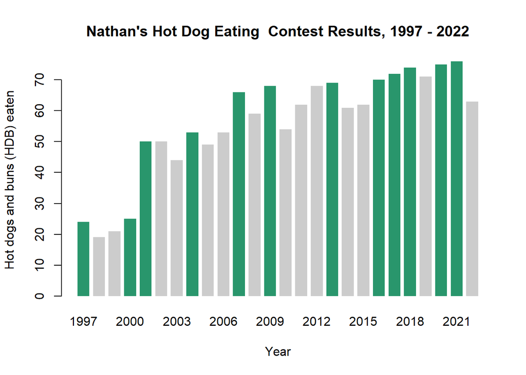

```r
# Highlighting records
fill_colors <- c()

for ( i in 1:nrow(df_men) ) {

  if (df_men$isRecord[i] == 1)
    fill_colors <- c(fill_colors, "#29966c")
  else
    fill_colors <- c(fill_colors, "#cccccc")
}

barplot(df_men$Hot.dogs.and.buns.eaten, names.arg=df_men$Year, col=fill_colors,
        border=NA, space=0.3, xlab='Year', ylab="Hot dogs and buns (HDB) eaten",
        main = "Nathan's Hot Dog Eating  Contest Results, 1997 - 2022")
```

## Editing the graph for publishing

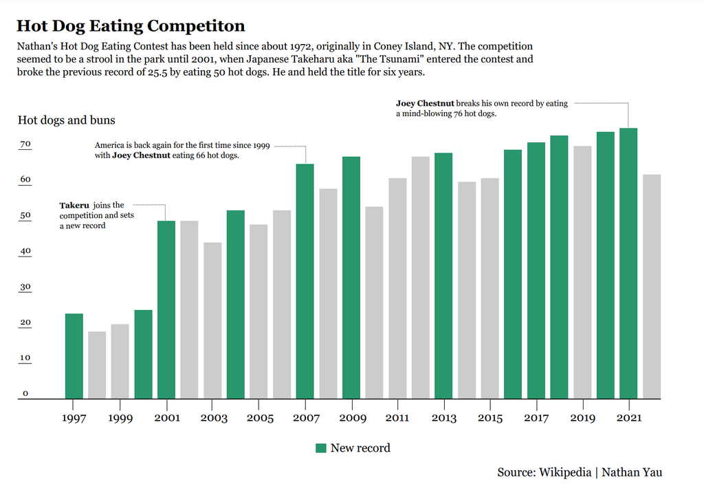

## End notes

### Review

When I started this project, I didn’t know much about R syntax, which explains why I spent a lot of time trying to understand how vectors, matrix, 2D array work. I have encountered many challenges, but hey, it didn’t stop me. I know it might seem like it is nothing for more experienced Data scientist, but for me it’s a big and motivating step towards my future bigger projects!

### Possible improvements

I stopped here, but I could have also extracted data from previous years and years when there were multiple competitions.

- MISSING_INFO = c(“1973”, “1968-1971”, “1976-1977”)
- MULTIPLE_CONTEST_IN_A_YEAR = c(1972, 1974, 1986, 1993, 1996)

### Bloopers :)

Blooper 1: The 2008 year seemed completely off because I extracted number 595 from “59 Eat-off: 5”. I fixed my regex pattern to extract only the first number.

Blooper 2: The plot heights were all the same because I inadvertently put the year inside the number of hot dogs eaten and buns. `df_men$Hot.dogs.and.buns.eaten = as.numeric(df_men$Year)`

Blooper 3: I was looping through length() of a 2D array instead of the number of rows. So I was getting an “out of bound” error.

Blooper 4: Before 2011, there was no “MEN’S” before the row, but I was trying to split the strings to remove a “MEN’S” that did not exist. Which explains why I got a data frame full of “NA”.

Blooper 5: At first I didn’t sort the data in ascending year, so I had to loop through the arrays from the end to create new records, which gave me 2 reversed vectors of records which did not match with the men and women arrays. Sorting by year before merging fixed it though.

Blooper 5: All the challenges I bumped on and forgot about :)